# Machine Learning at the service of the vineyard

Allan Mivelaz, Mazen Nasser, Giacomo Russo, Vincent Saudan, Adrian van Kampen

25 May, 2021

# Introduction

As part of the Machine Learning in Business Analytics course taught at HEC Lausanne by Professor Marc-Olivier Boldi, we had a lot of fun doing the following project: Machine Learning at the service of the vineyard.

But how did we get the idea? When we had to decide on a common idea, the choice was difficult due to our various passions. Therefore, it was not easy to agree on an idea that could get us all excited about a common project especially since this project has always been valuable to everyone. It is thus during one of those warm evenings all together that this project was born. Something special brought us together: an excellent bottle of red wine.

We were not doing anything new though. The history of wine is not new either. Since ancient times and even before, wine has accompanied the development of our civilization. Wine already represented conviviality, wealth and even power.

Furthermore, like many other fields the wine world is a sector already strongly impacted by artificial intelligence. Whether it is through technologies dedicated to the production or the evaluation of the quality of the product. We therefore saw this as an excellent opportunity to apply our newly developed skills to deepen the analysis of wine quality, a field (i.e., wine tasting) in which we had little technical knowledge. We also wanted to bring a business perspective on how our project could be applied in the future.

Contrary to what one might think, the wine industry is constantly improving. At present, innovation is aimed at responding to environmental, quality, market, and traceability issues, which are ever-increasing concerns for consumers. To the delight of wine lovers, many applications and physical products have emerged to further enhance the taste experience of a wine tasting. Thus, many startups have emerged in the last five years, even seeing the emergence of a new movement, WineTech. On the other hand, many of these startups have also closed since the wine world is still perceived as conservative. The emergence of digital technologies, artificial intelligence, Big Data, and many others are therefore responsible for recent and future developments in the industry.

Although we are aware that this project is rather popular and therefore not new, we decided to innovate with the many different models of supervised and unsupervised learning we used and their comparison which allowed us to extract value from our data as you will discover later.

# Data

### Sources

Two datasets were used as a reference. We used the [Wine Quality Data Set](https://archive.ics.uci.edu/ml/datasets/wine+quality) available on the UCI repository. These two datasets therefore include the red and white variants of the Portuguese Vinho Verde wine.

### Description

The Red wine dataset contains 1599 instances for 12 features, including a quality feature which is an output variable based on sensory data with a score ranging from 0 to 10. The other features are input variable based on physicochemical tests and are as follows:

- **fixed acidity** - *most acids involved with wine or fixed or nonvolatile (do not evaporate readily)*
- **volatile acidity** - *the amount of acetic acid in wine, which at too high of levels can lead to an unpleasant, vinegar taste*
- **citric acid** - *found in small quantities, citric acid can add ‘freshness’ and flavor to wines*
- **residual sugar** - *the amount of sugar remaining after fermentation stops, it’s rare to find wines with less than 1 gram/liter and wines with greater than 45 grams/liter are considered sweet*
- **chlorides** - *the amount of salt in the wine*
- **free sulfur dioxide** - *the free form of So2 exists in equilibrium between molecular So2 (as a dissolved gas) and bisulfite ion; it prevents microbial growth and the oxidation of wine*
- **total sulfur dioxide** - *amount of free and bound forms of So2; in low concentrations, So2 is mostly undetectable in wine, but at free So2 concentrations over 50 ppm, So2 becomes evident in the nose and taste of wine*
- **density** - *the density of water is close to that of water depending on the percent alcohol and sugar content*
- **pH** - *describes how acidic or basic a wine is on a scale from 0 (very acidic) to 14 (very basic); most wines are between 3-4 on the pH scale*
- **sulphates** - *a wine additive which can contribute to sulfur dioxide gas (So2) levels, wich acts as an antimicrobial and antioxidant*
- **alcohol** - *the percent alcohol content of the wine*

The table below shows the first 6 instances.

##### Overview of the Red Wine Dataset

| fixed acidity | volatile acidity | citric acid | residual sugar | chlorides | free sulfur dioxide | total sulfur dioxide | density | pH | sulphates | alcohol | quality |
| --- | --- | --- | --- | --- | --- | --- | --- | --- | --- | --- | --- |
| 7.4 | 0.70 | 0.00 | 1.9 | 0.076 | 11 | 34 | 0.998 | 3.51 | 0.56 | 9.4 | 5 |
| 7.8 | 0.88 | 0.00 | 2.6 | 0.098 | 25 | 67 | 0.997 | 3.20 | 0.68 | 9.8 | 5 |
| 7.8 | 0.76 | 0.04 | 2.3 | 0.092 | 15 | 54 | 0.997 | 3.26 | 0.65 | 9.8 | 5 |
| 11.2 | 0.28 | 0.56 | 1.9 | 0.075 | 17 | 60 | 0.998 | 3.16 | 0.58 | 9.8 | 6 |
| 7.4 | 0.70 | 0.00 | 1.9 | 0.076 | 11 | 34 | 0.998 | 3.51 | 0.56 | 9.4 | 5 |
| 7.4 | 0.66 | 0.00 | 1.8 | 0.075 | 13 | 40 | 0.998 | 3.51 | 0.56 | 9.4 | 5 |

The second dataset is the one for White wines and contains 4898 instances with the same 12 features seen above.

##### Overview of the White Wine Dataset

| fixed acidity | volatile acidity | citric acid | residual sugar | chlorides | free sulfur dioxide | total sulfur dioxide | density | pH | sulphates | alcohol | quality |
| --- | --- | --- | --- | --- | --- | --- | --- | --- | --- | --- | --- |
| 7.0 | 0.27 | 0.36 | 20.7 | 0.045 | 45 | 170 | 1.001 | 3.00 | 0.45 | 8.8 | 6 |
| 6.3 | 0.30 | 0.34 | 1.6 | 0.049 | 14 | 132 | 0.994 | 3.30 | 0.49 | 9.5 | 6 |
| 8.1 | 0.28 | 0.40 | 6.9 | 0.050 | 30 | 97 | 0.995 | 3.26 | 0.44 | 10.1 | 6 |
| 7.2 | 0.23 | 0.32 | 8.5 | 0.058 | 47 | 186 | 0.996 | 3.19 | 0.40 | 9.9 | 6 |
| 7.2 | 0.23 | 0.32 | 8.5 | 0.058 | 47 | 186 | 0.996 | 3.19 | 0.40 | 9.9 | 6 |
| 8.1 | 0.28 | 0.40 | 6.9 | 0.050 | 30 | 97 | 0.995 | 3.26 | 0.44 | 10.1 | 6 |

# Exploratory data analysis

### Red vs. White - Quality

In this section, we will first look at the distribution of the quality scores received by the two types of wines (i.e. red or white) as well as the overall distribution.

The first important point to note here is that none of the wines received the highest score (i.e., 10) or a quality score below 3. In addition, it can be observed that only a few white wines can be qualified as exceptional since they received a score of 9 while no red wine had this honor (only 5 wines received a score of 9 while 30 wines received a score of 3).

Overall, a fairly clear trend can be defined for both types of wine. It appears that the vast majority of wines received a score of 5 or 6. Thus, we can draw a first conclusion that a wine with a score of 4 can be defined as bad, a score of 5 being an average wine, a score of 6 a good wine, then excellent for a score of 7, and finally the scores of 8-9 are reserved for the vintage wines.

In other words, it is difficult here to draw any other conclusion than the one that one would expect, namely that the majority of the wines can be classified as average or good. It would seem that in general a white wine is more easily classified in the latter category while a red wine is judged rather equally between these two categories.

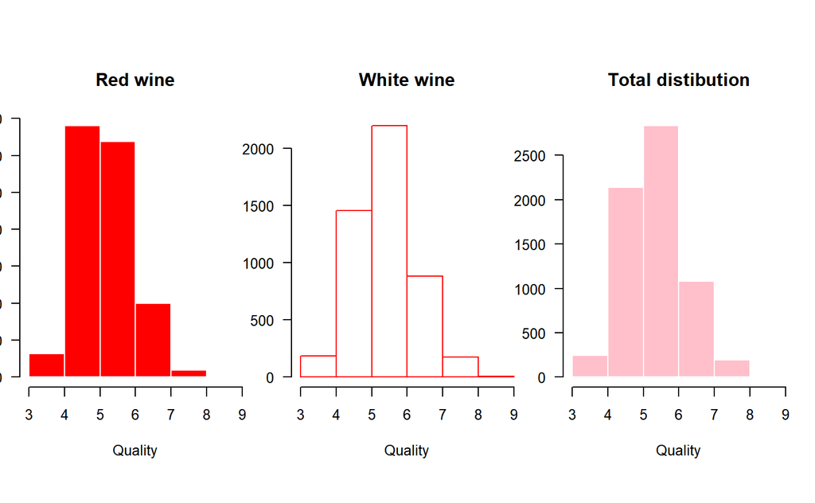

### Features distibution

Then, although the distribution of the different variables have all been plotted. It is interesting here to focus on the following: volatile acidity, citric acid, total sulfur dioxide, pH, and alcohol.

To start with the *volatile acidity*: as previously mentioned, it has been observed that a level too high could lead to an unpleasant,vinegar taste. In this case, most of the wines have a *volatile acidity* below (0.8).

Regarding *citric acid*, we know that in small quantities it adds freshness and flavor to wines. It is therefore not surprising to find it in wine in small quantities ranging from 0 to 0.75 (g/dm3).

Again, in low concentrations, *total sulfur dioxide* (So2) is mostly undetectable in wine, but at free So2 concentrations over 50 ppm, So2 becomes evident in the nose and taste of wine. We see here very clearly a distinction in the distribution.

To finish with the two features that speak to most people, *pH* and *alcohol*, usually wines are between 3-4 on the pH scale which can be observed for the wines present in our dataset with a tendency towards the lower range. The *alcohol* content is certainly the best known measure, with a range of 8 to 14 percent alcohol for our wines.

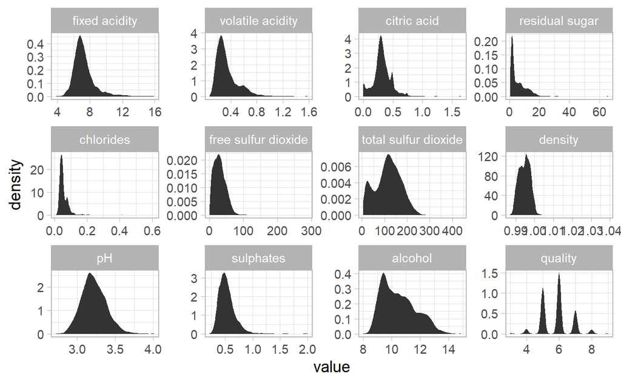

### Correlation matrix

The strongest correlation is found to be between free sulfure dioxide-total sulfur dioxide (0.72) followed by alcohol-density (-0.69) and residual sugar-density (0.55). These sets of features seems to all have more than meaningful correlation (>0.5).

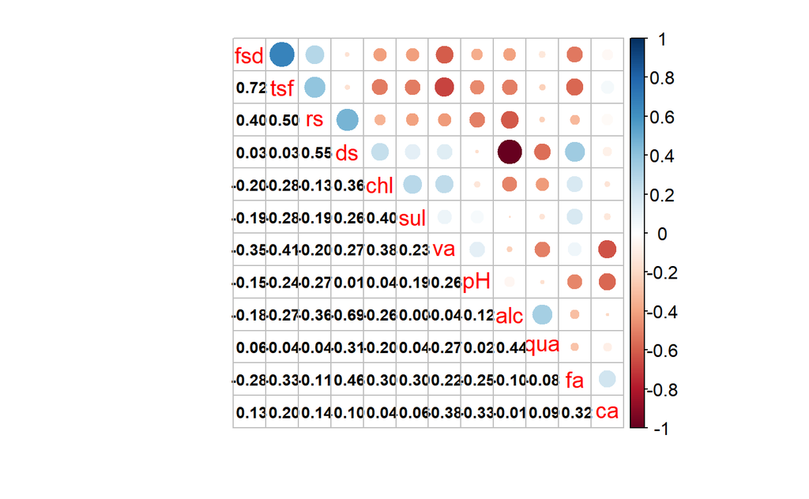

### Quality vs. features exploration

The median values here show a slight downward trend for *fixed acidity* and *volatile acidity* the higher the wines were rated, while it is the opposite trend for *citric acid*. Since *volatile acidity* at higher level increases unpleasant vinegar like taste, it can be inferred that *volatile acidity* generally decreases quality.

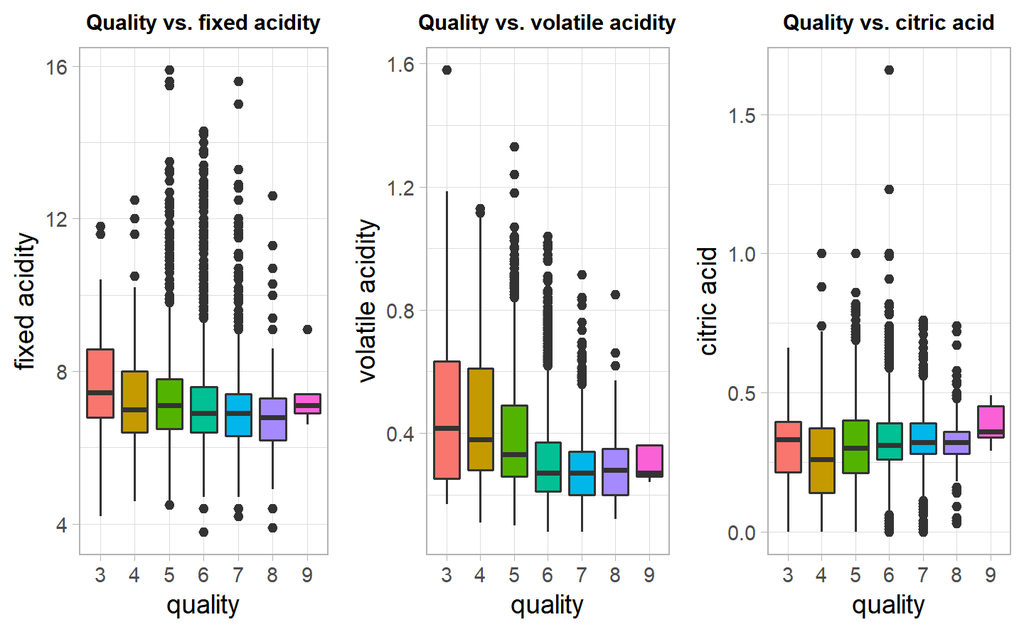

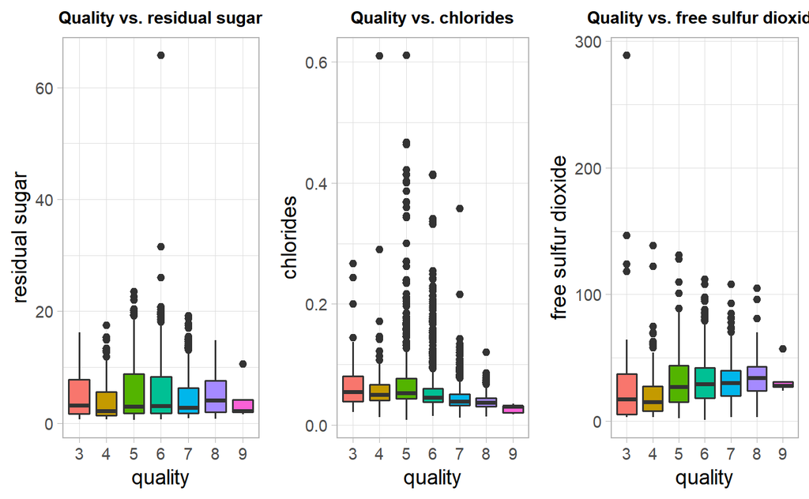

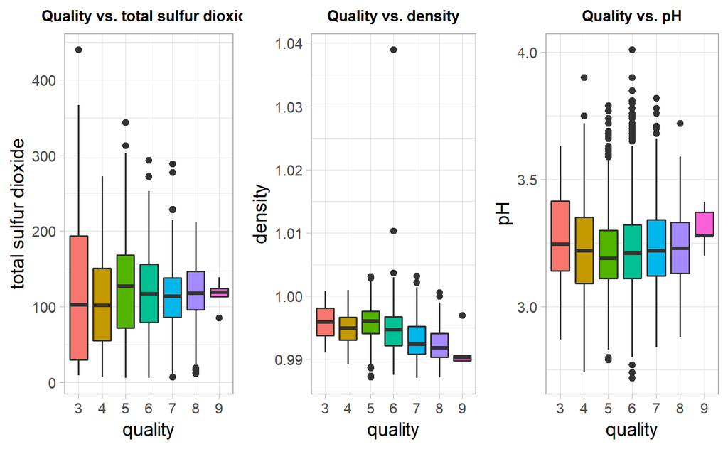

# Data Management

### Categorical Data Transformation & Scaling

First thing we did was feature scaling before creating any model. This will allow us to bring every feature in the same footing without any upfront importance. We have also added a binary categorical variable column. In other words, wines with a score strictly below 6 were categorized as “bad” while those with a score of 6 or higher were categorized as “good”.

#### Data Splitting

We have divided the data into two groups such as train data and test data using 80/20 ratio. We will train each classifier based on the trained data and predict the power of classifier on the test data. So, each classifier will be able to show all the performance metrics such as accuracy. We are also going to build many plots so that it will be easier to understand it in a better way. What we observe is that there are 744 red wines classified as “Bad” and 855 “Good”, while 1640 white wines were categorized as “Bad” and 3258 “Good”.

To make fair predictions, sampling is needed especially for white wine

### Data Sub-Sampling

We will transform our training set (but NOT testing set) to a more balanced and fair data to get the best sensitivity/specificity later on. We use a subsampling method in order to get 50%-50% Good-Bad classes for both Red and white Wine.

Before sampling Training Sets: Red: Bad 744 - 855 Good White: Bad 1640 - 3258 Good

After our sub- sampling: Red: Bad 595 - 595 Good White: Bad 1312 - 1312 Good

Now both Training sets are balanced and we dont have prediciton bias in our models.

### Cross Validation

In order to make sure we have a solid training set we conducted a CV by training a model for 20 validations and tested on both red and white.

**C.V. Stats - Red Wine**

| Accuracy | 0.759 |
| --- | --- |
| Kappa | 0.518 |
| Sensitivity | 0.768 |
| Specificity | 0.751 |
| Balanced Accuracy | 0.760 |

**C.V. Stats- White Wine**

| Accuracy | 0.731 |
| --- | --- |
| Kappa | 0.443 |
| Sensitivity | 0.779 |
| Specificity | 0.707 |
| Balanced Accuracy | 0.743 |

#### Bootstrap

We used the 632 method to avoid the fact that instances can be repeated in the training set and thus could create a bias.

The results of the bootstrap method were approximately the same as the Cross Validation in terms of Accuracy measures.

**Conclusion:** Our CV and Boostraping show us that the balanced training sets choices are good enough in accuracy to conduct further Machine Leaning models.

# Supervised Learning Models

In this section, we Will apply 5 Super Machine Learning Models to check their accuracy both on Red and WHite wine quality. We will also be applying Categorical(binary) classification as well as discrete numerical models where applicable.

We will briefly describe our use of each model before concluding with our model scores and proceeding to tuning our models.

**Categorical Quality Prediction** We will derive the prediction accuracy and probability outcome for each of our models. Below we will describe Each model and our approach in its use in order to reach the final Summary table with Accuracy Score for each wine dataset.

**Numerical discrete quality prediction** For our regressions and numerical classifications we will be visually showing results of our models used and will also score using technical accuracy measures these models in the scoring section before tuning some of them.

### KNN

#### Binary Categorical KNN on Quality category

We ran a KNN model using Trial and Error in order to check the best accuracy under different K assumptions. We concluded with a K=2 for both Red and White datasets.

Although more details are available in the summary stat table but our red Wine dataset has more than 80% accuracy and White Wine around 77%.

#### Numerical Classification under KNN regression

Also using K=2, we ran a KNN regression on the numerical quality and plotted the results to be able to see the visual accuracy

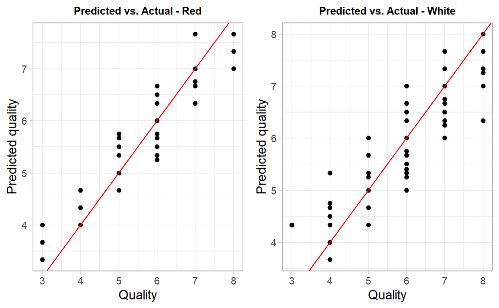

**Notes on the KNN**

At first glance, KNN regression seems to be less accurate at predicting the discrete quality variable compared to the high accuracy of KNN classification. Moreover, we can see and observe the higher accuracy in Red Wine compared to White.

### Naive Bayes

We conducted Kernel and non kernel use for Naive Bayes plotting and decided not to use kernel as the distribution functions seemed to fit well without it. Testing this theory we noticed that Kernel did not bring much improvement to our accuracy measures hence why the ND model we went for in our prediction is the standard one. Naive BAyes has been fitted to predict our Quality Category Good or Bad wine

#### Naive Bayes without Kernel

Using a normal Naive Bayes for both our Datasets we got a 75% and 69% accuracy for each of our Red and White sets respectively.

#### Naive Bayes using Priors

We calculated the Ratio of Good/Bad wine quality in our full data set for each of red and white to derive the ratio of Good/All and Bad/all and used them as conditional prior probabilities to fit the new NB models

We get 75% and 70% for each Red and White wine respectively

**Notes on Naive Bayes** Accuracy For White wine is not satisfactory but it does however improve while using the Priori conditional probability that it takes into account the Ratio of Good to Bad Quality. Predicting Red Wine quality is clearly more accurate. One thing we do notice is low Kappa for all the model.

### Linear-Log Regression

We conducted a Linear regression model on the numerical quality for red and white wines using the best stepwise regression , using AIC, model. We used the stepwise LM model to predict and plotted the following charts:

```
#> integer(0)
#> integer(0)
```

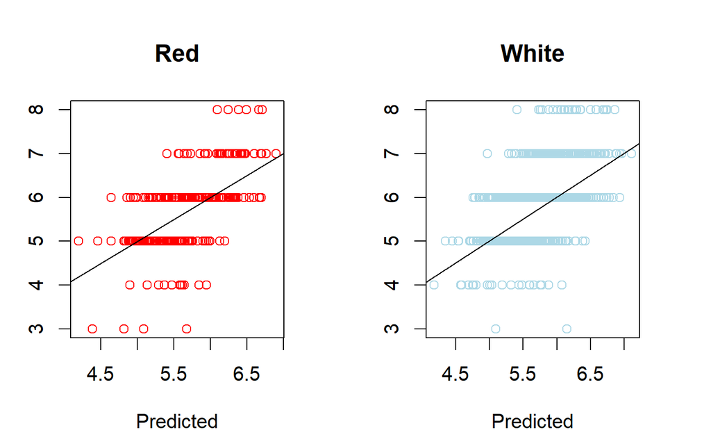

**Notes on Linear Regression** We again notice that predicting numerical discrete quality shows alot of error in linear models moreso for white compared to red wine.

### Logistic Regression

Also using a stepwise logistic regression model we predicted our categorical Good/Bad quality for each red and white dataset with a standard cutoff point at 0.5.

A 76% accuracy for our Red wine and 73% for our White wine, we also visualize the prediction 2-class tables in boxplots

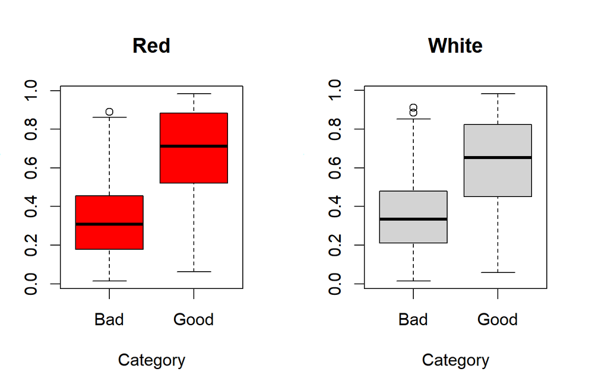

**Notes on Logistic Regression** Also a small bias of prediction quality towards red wine but nonetheless fair accuracy for both at the standard 0.5 cutoff threshold.

### Classification and Regression Tree

We will be using a Categorical Classification tree for Good-Bad wine and another Regression Tree to predict our Quality score.

#### Classification Tree on Good/Bad Quality

**Red Wine**

First We check the fitted Tree before pruning

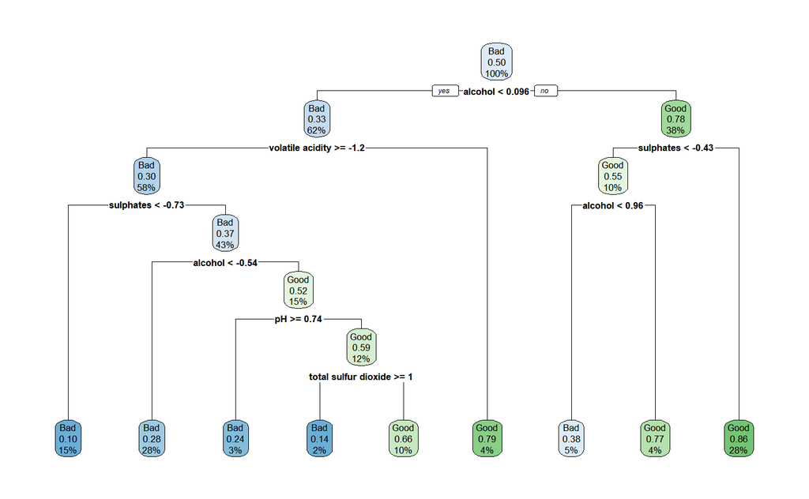

Then we plot the CP graph to check whether any pruning can be done…

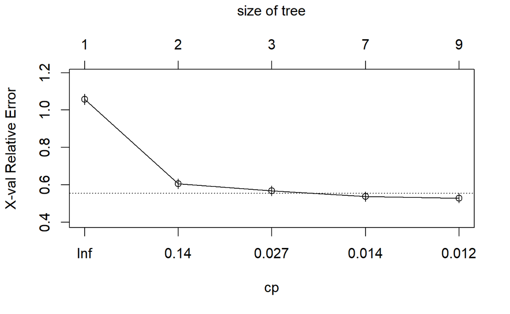

Doing just that, we get the following pruned tree

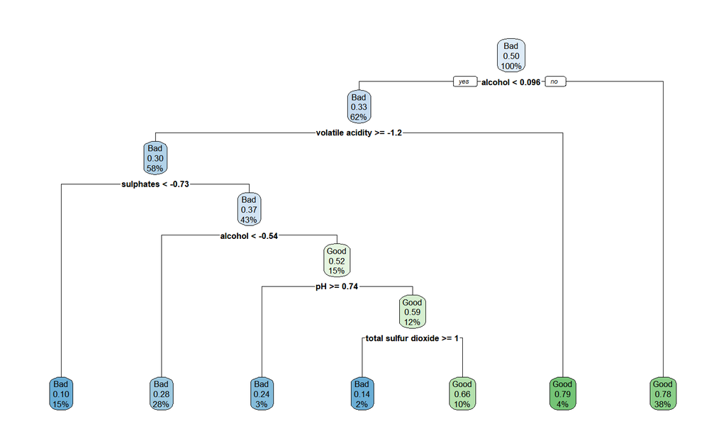

*Note: We also ran Autoprune for the Trees and concluded they are not better or as good as the manually pruned trees so we kept the originals for the analysis.*

Prediction using the pruned tree gives a 76% Accuracy, we can also visualize the below 2-class summary table for predicting Quality category

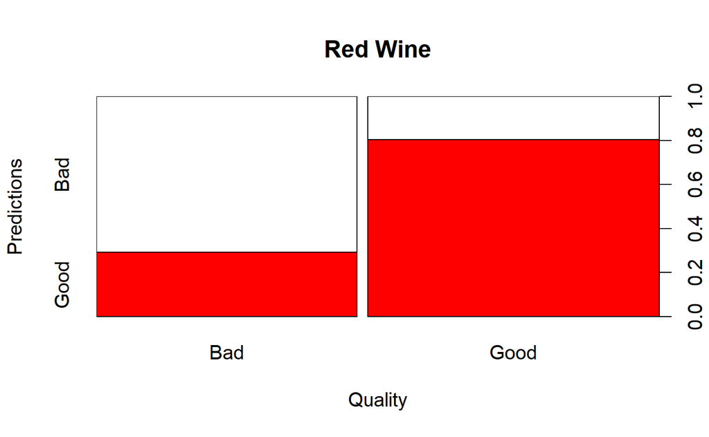

Following the same process for white Wine we conclude that we are able to prune at 7 nodes with a CP=0.011, doing just that we get the following pruned tree

**White Wine pruned tree**

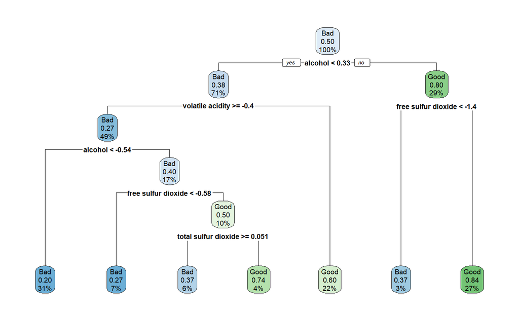

The following shows the prediction table for White Wine

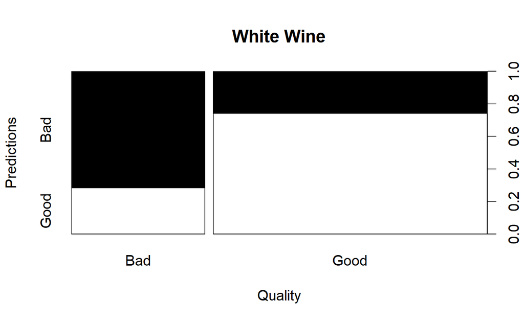

#### Regression Tree on numerical Quality

Using the numerical quality as Y variable we run regression trees for both datasets:

**Red Wine**

For Red wine our initial Tree had 13 nodes, a CP graph suggested 4 nodes with a cp=0.028. Our final pruning tree becomes the following:

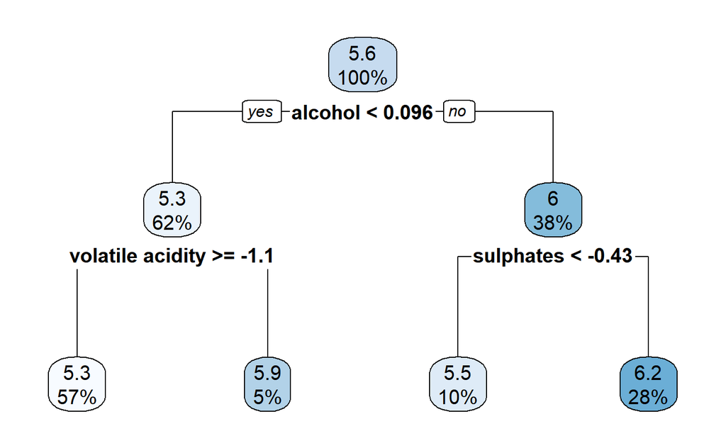

We plot the graph to show the predicted vs the actual quality and check the accuracy

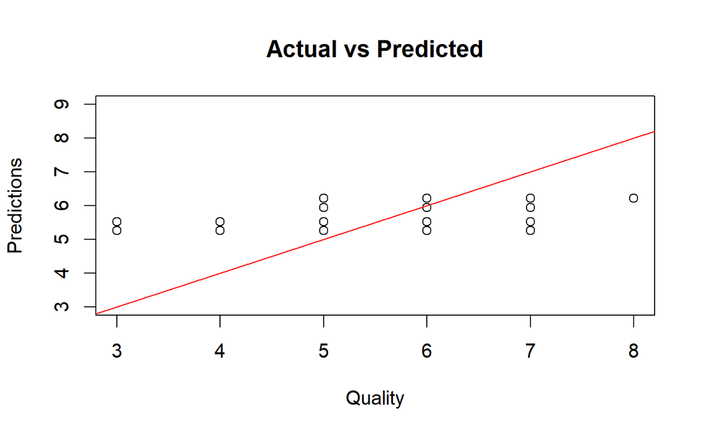

**White Wine**

Doing the same for White wine our initial tree of 9 nodes is reduced with a cp=0.015 to nodes 6 nodes

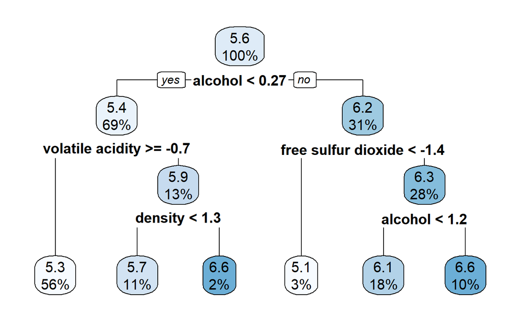

And the visual representation shows:

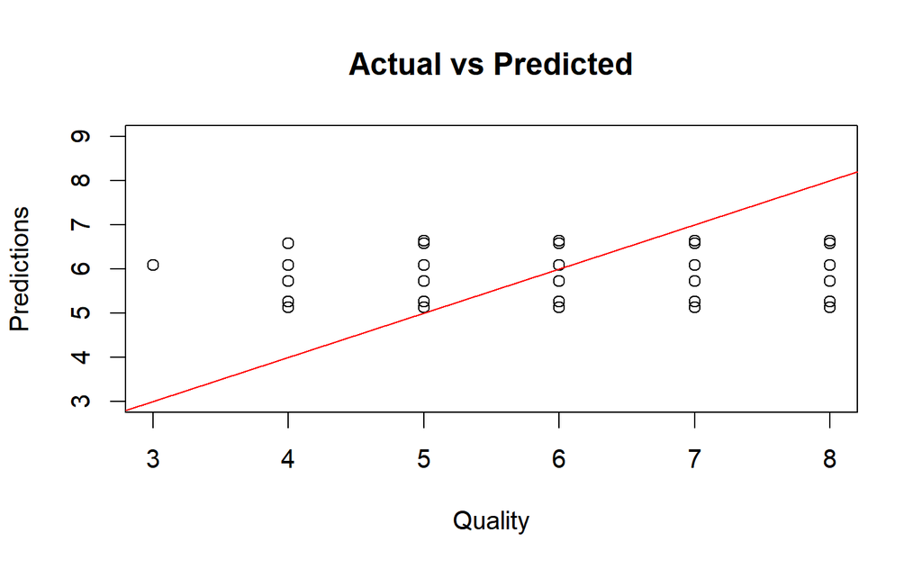

### Support Vector Machines

We conduct an SVM model with different Kernel types on both Red and White sets for the Categorical quality variables

We receive the following results of Accuracy: KERNEL - RED - WHITE: Linear - 74% - 73% Radial - 81% - 78% Polynomial - 78% - 76%

##### Tuning Hyperparameters

We choose the best accuracy model for each data sets and run a training model using grid search to train and tune our best models in order to push up accuracy

We use a train control Cross Validation (10 times) method

For the RED Wine data set we have the radial kernel as the one with the highest accuracy. we created a gird of different sigmas and costs and tuned the model and derived the following parameter optimals

**Red Wine**

For the Tuning of Red Wine dataset under a Radial method we took the following grid: expand.grid(sigma = c(0.01, 0.05, 0.1,0.15), C = c(0.1,0.25,0.50,1, 10, 100)) We got the following results

```
#>    sigma  C
#> 17   0.1 10
```

We then choose the best hyperparameters for our model in order to re-fit and check the improvement in Accuracy. the result is the same, Accuracy of 81% which is the standard SVM radial model

**White Wine**

For our White dataset , although Radial also is the best Accuracy model but we will try to optimise on Polynomial to check whether we can reach the same accuracy.

For the Tuning of White Wine dataset under a Polynomial kernel we took the following grid: expand.grid(degree = c(1,2,3), scale = c(0.001, 0.01, 0.1), C = c(0.1,1,10)) we get the following results:

```
#>    degree scale  C
#> 24      3  0.01 10
```

Fitting the tuned model we get an amazing accuracy of 82%

**Notes on SVM** SVM seems to be a good classification model for our categorical quality of wine for both colors. Surprisingly the tuning of the polynomial model provided much better improvement for white compared to the tuning of the Radial model of the red dataset. Nonetheless both Red and White tuned models are good predictors.

### Model Scoring

In order to review our models so far and decide whether we can improve on them we will score our models using different Techniques and attempt to fine tune them to achieve better prediction results.

#### Binary classification Models

##### Two Class Summary

Retrieving the stats for our top 5 models from each method for the Categorical Classification of wine quality

**Statistics**

|  | Red Wine ROC | Red Wine Sens | Red Wine Spec | White Wine ROC | White Wine Sens | White Wine Spec |
| --- | --- | --- | --- | --- | --- | --- |
| knn | 0.932 | 0.775 | 0.858 | 0.878 | 0.844 | 0.744 |
| NB | 0.823 | 0.762 | 0.746 | 0.754 | 0.701 | 0.681 |
| GLM | 0.830 | 0.768 | 0.751 | 0.805 | 0.779 | 0.707 |
| Tree | 0.818 | 0.709 | 0.805 | 0.787 | 0.717 | 0.742 |
| SVM | 0.887 | 0.868 | 0.751 | 0.890 | 0.897 | 0.780 |

##### Entropy

Calculating the Entropy for each of the models on both datasets

**Log-loss**

|  | Red Wine logLoss | White Wine logLoss |
| --- | --- | --- |
| knn | 1.046 | 1.581 |
| NB | 0.621 | 0.800 |
| GLM | 0.505 | 0.546 |
| Tree | 0.519 | 0.558 |
| SVM | 0.430 | 0.446 |

KNN seems to have the highest Accuracy but also highest Entropy , a close second is the SVM which has really good accuracy with the lowest Entropy

##### Tuning Using ROC

In order to find our optimal Cut-OFF point or threshhold we tune our models using the best ROC method to derive the optimal threshhold. (Note that our SVM models have already been turned using grid search, we will attempt to tune our KNN, NB, Log and CART).

**Red Wine**

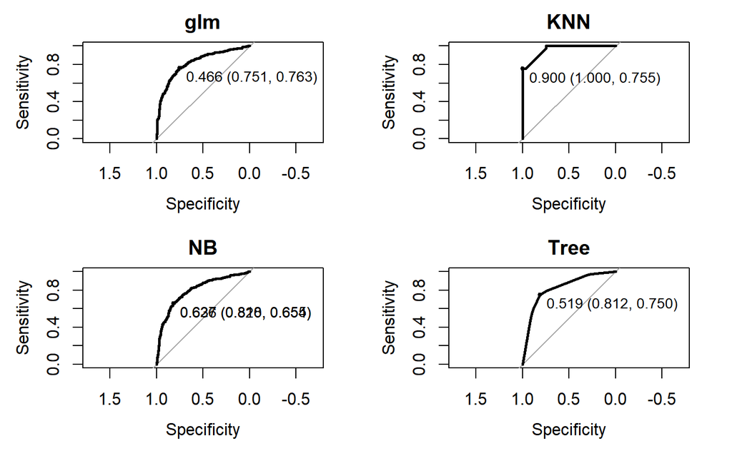

we get the following Cutoffs for our models: - KNN 0.9 - NB 0.63 - GLM 0.47 - Tree 0.52

Applying these Thresholds we get the following prediction Accuracies

**Red Wine - ROC Tuned**

|  | Accuracy | Kappa |
| --- | --- | --- |
| GLM | 0.7625 | 0.524163568773234 |
| KNN | 0.875 | 0.752005269888015 |
| NB | 0.759375 | 0.523109081055973 |
| Tree | 0.775 | 0.550789627607721 |

**White Wine**

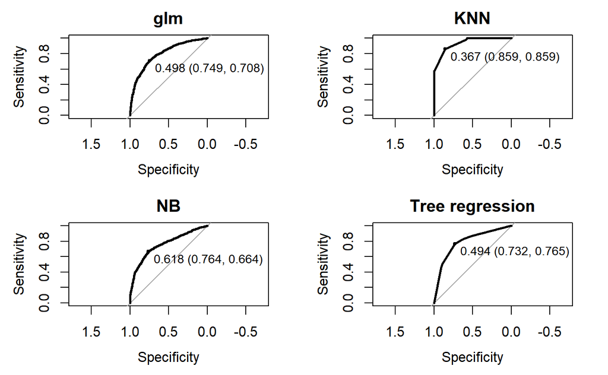

we get the following Cutoffs for our models: - KNN 0.37 - NB 0.62 - GLM 0.50 - Tree 0.49

Applying these Thresholds we get the following prediction Accuracies

**White Wine - ROC Tuned**

|  | Accuracy | Kappa |
| --- | --- | --- |
| GLM | 0.730612244897959 | 0.442790869971614 |
| KNN | 0.785714285714286 | 0.550880562163106 |
| NB | 0.678571428571429 | 0.352585881464704 |
| Tree | 0.736734693877551 | 0.439122969693474 |

#### Regression / multi-class Models

For all our models that predict numerical quality scores we use the RMSE and MAE metrics to check accuracy

**Red Wine**

|  | RMSE | MAE |
| --- | --- | --- |
| LM | 0.691 | 0.523 |
| KNNreg | 0.260 | 0.126 |
| Treereg | 0.655 | 0.481 |

**White Wine**

|  | RMSE | MAE |
| --- | --- | --- |
| LM | 0.725 | 0.558 |
| KNNreg | 0.312 | 0.168 |
| Treereg | 0.750 | 0.592 |

**Notes on Numerical Model Scores** Although Visually not appealing and not as convincing as binary classification models, but between our regression models we find that KNN is by far the best predictor with lowest error in accuracy for both Red and White wine. Prediction quality for Red is slightly higher.

### Random Forest

We will apply random forest and Ranger models in order to see how much we can improve the accuracy of our CART models

We use a training control of Repeated Cross-Validation with 3 repeats of 5 Validations.

The Random Forest and Ranger will be fitted on the balanced training sets. Ranger will be trained by using “Impurity” as an optimisation factor.

**RED WINE**

We plot the Random Forest Error / Tree number charts

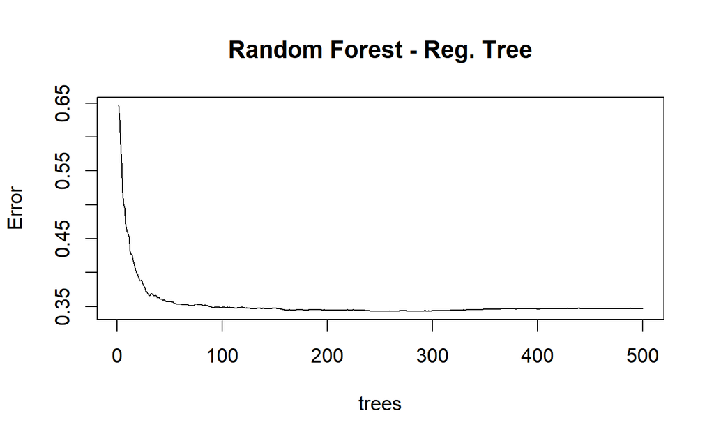

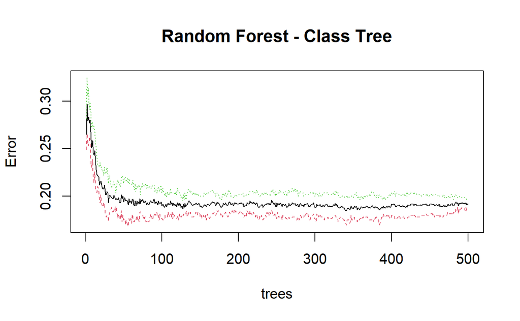

After fitting Random forest model on our training set and assessing the prediction accuracy on our testing set we get the following results:

-*Accuracy Increases from 0.76 to 0.95 using the Random forest Vs the Class. Tree*

Using a Ranger model we get the following:

-*RMSE is at 0.38*

-*Accuracy is at 0.96*

**WHITE WINE**

Same plots of Errr/ Tree number

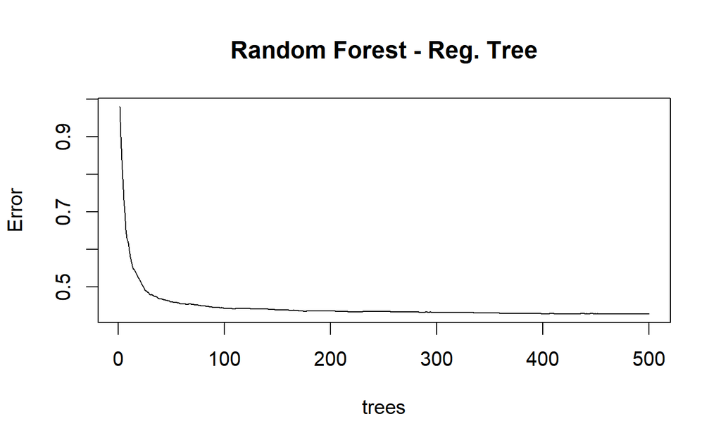

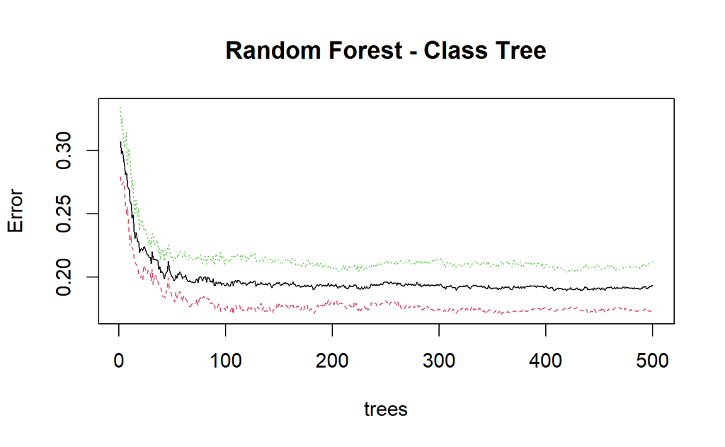

Fitting a Random Forest yields the following improvements:

-*Accuracy increases for the Class. tree model from 0.73 to 0.91*

Using the Ranger method:

-*RMSE drops to 0.48*

-*Accuracy jumps to 0.91 as well*

**Notes** It is very evident that the Random Forest and Ranger is a major improvement in accuracy for both Classification and Regression Tree models. One difference is that in the White dataset both models led to the same result while in the red each had an improvement advantage but still in the same proximity.

# Unsupervised Learning Analysis

Given that the Wine Dataset was already used in class in Unsupervised Learning, we decided to go further in our choices of methods and analysis of the datasets.

### Clustering

We have conducted a full clustering model using the whole dataset and compared it to our BALANCED training set for both RED and WHITE wine data in order to see whether Sub-Sampling the data provides any added-value to our models.

#### Hierarchical Clustering - AGNES

In this model we will be using the Euclidean distance and will be linking the clusters using the WARD method to minimize total “within” sum of squares (unlike the manhattan and complete linkage used in class)

For the AGNES method in clustering we will only Use our *Red Wine* Dataset, although we analyzed both in our codes.

**Full Dataset**

At a height of 250 we can split our dendogram to 4 main clusters

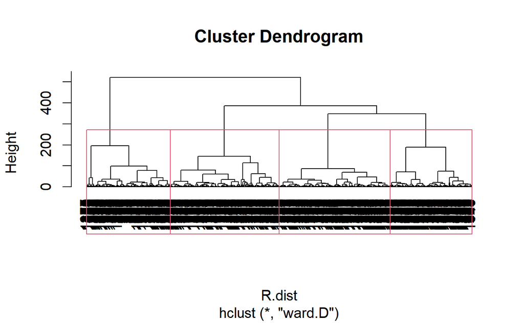

We also conduct a component Analysis to check the Variable representation in each cluster

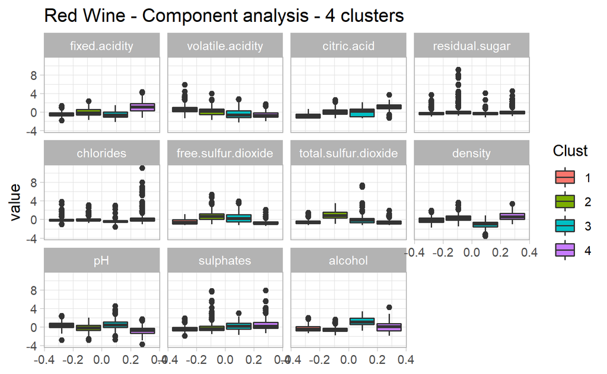

**Balanced Set** Using our training dataset which is 50-50 balanced we follow the same method. This time at the same height of 250 we cut into 3 clusters

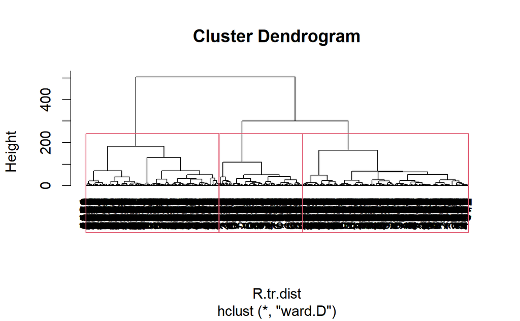

Moreover, we can see more clarity in variable importance and representation with 3 clusters

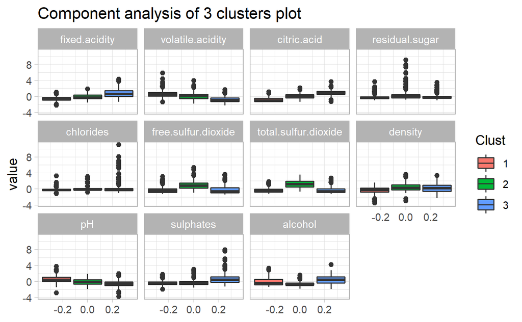

**Optimal Cluster Choice**

We will just portray the WSS and Silhouette methods for cluster numbers for both our Full Red dataset and our Balanced Dataset

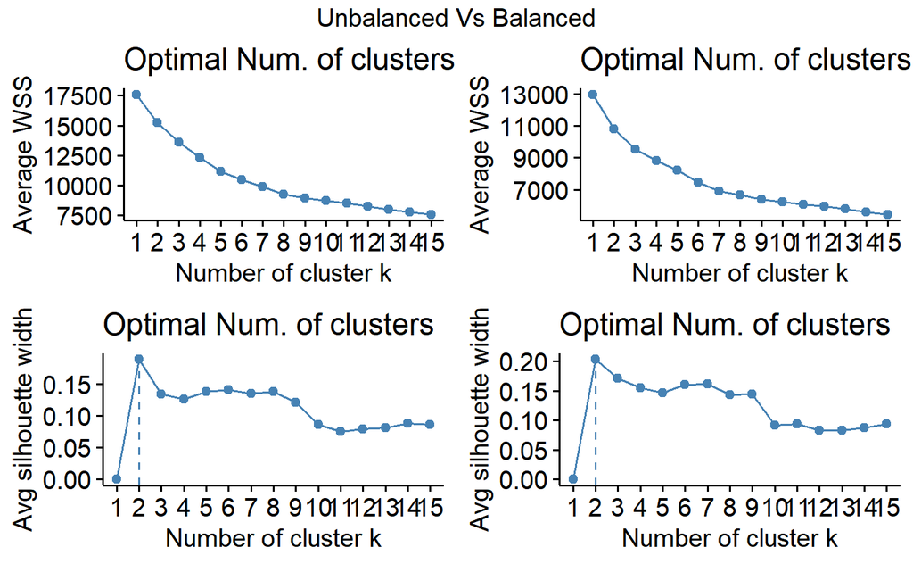

**Notes** Not much difference in between the two sets. Same thing for the White wine datasets, not a significant difference. Both balanced and full set optimise at 2 clusters although the WSS might suggested more (4-5)

#### Partitionning

##### K-MEANS

For our K-means we will only portray the analysis on the White Wine dataset

We will focus the difference between balanced and unbalanced dataset using also wss and silhouette

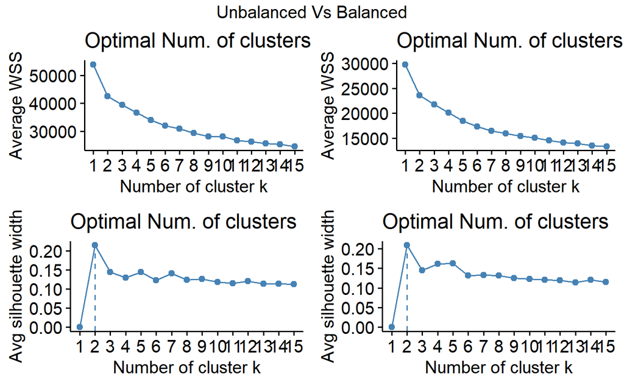

Taking 2 clusters for the balanced and visualizing them graphically:

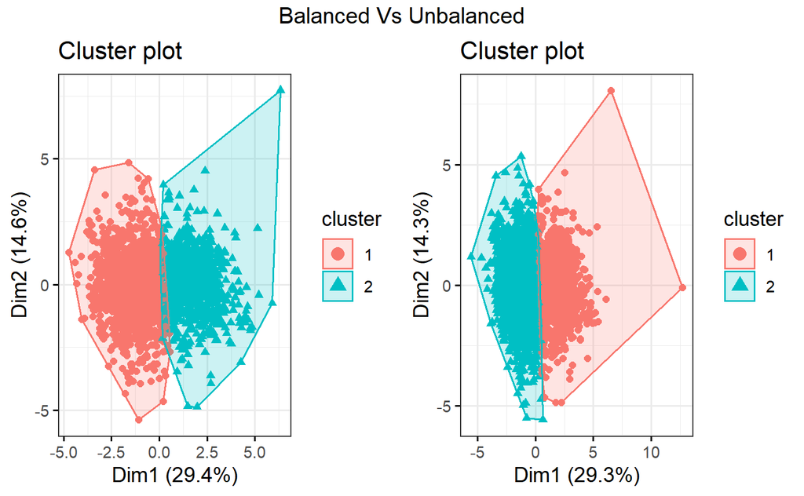

Again we see no major difference between using a balanced and unbalanced dataset while clustering under Kmeans method with 2 clusters.